# Assignment1

John Hamre III

November 2, 2017

## Introduction

ATP-binding cassette (ABC) transporters are ubiquitously found in nature and are categorized as membrane-transport, ATP-dependent pumps. The transporters are bound to the membrane and move substrates inside or outside of the organelle, termed “influx” and “efflux,” respectively (1). ABC transporters are active transporters, and therefore move ions or molecules against a concentration gradient and require energy, ATP, to do so (2). The transporters can move a wide variety of molecules across membranes to include; ions, sugars, amino acids, and other molecules and chemical compounds. They are found on various membranes within the cell such as the mitochondrial, endoplasmic reticulum, or cell surface membranes. ABC transporters contain an ATP binding cassette, also known as the ‘nucleotide-binding domain’ (NBD) which contains several highly conserved motifs, including the Walker A, Walker B, ABC signature motif, the H-loop and the Q-loop (1,3,4). The NBD domain is located at the core of the ABC transporter, where there consist four domains in total, two NBD domains and two trans-membrane domains (TMDs), which contain several hydrophobic α-helices that span the lipid bilayer. The two NBDs bind and hydrolyze ATP thereby providing the driving force for transport, while the TMDs participate in substrate recognition and translocation across the lipid membrane (1). Numerous ABC transporters are translated as “half-transporters” because they code for two subunits that bind as homodimers or heterodimers (4).  
ABC transporter proteins of this study were all homodimers that consisted of duplicate chains. Two of the four proteins were heterotetramers, however, and contained two sets of homodimers. ABC binding cassette were specifically of interest in this investigation, and consequently only one duplicate chain in each of the heterotetramers was investigated. In these two cases, the chains that most closely matched “typical” ABC transporter motifs and sequences were selected as those to be examined. Results from this research showed conservation of sequences and structures across all four proteins examined.

## Random protein selection

A “pseudo-random” sample generator was used to generate proteins by utilizing R code. The “sample” and “set.seed” algorithms allows the user to generate random numbers within a sample and then set it so that it can be subsequently found again. The number “731108” was chosen for the “set.seed”" function because the class number is BINF 731 and numbers 10 and 8 represent the user’s name alphabetically. The resulting numbers generated from the 14 samples were 13,12,9, and 6. Code input and output are below.

```r
#Code in R
set.seed(731108)
sample(1:14,4)
```

```
## [1] 13 12  9  6
```

## Interactive molecular visualization tools

13|4HLU Energy-coupling factor transporter ATP-binding protein [Thermotoga maritima], UniProtKB - Q9X1Z1

12|4G1U Hemin transport system ATP-binding protein [Yersinia pestis], UniProtKB - Q56993

9|1G6H Branched-chain amino acid ABC transporter ATP-binding protein [Methanocaldococcus jannaschii], UniProtKB - Q58663

6|1G29 Maltose ABC transporter protein MalK [Thermococcus litoralis], UniProtKB - Q9YGA6

## Multiple sequence alignment

[Fasta](http://binf.gmu.edu/jhamre/) sequences were collected from the PDB links found through uniprot and subsequently added to a notepad text editor for later copy and paste into alignment algorithms. Proteins 13 and 12 both entailed four chains with 2 sets of heterodimers, 1 set that was necessary to eliminate based on homogeneity to ABC transporters. The superfluous proteins were eliminated based on [Clustal Omega](https://www.ebi.ac.uk/Tools/msa/clustalo/) alignment and phylogenetic tree results. Initially, 12 A, B chains were rejected through the multiple sequence alignment tool. Once removed, the remaining 5 fasta sequences were again aligned. The resulting alignment was analogous for both 13 A, B chains and 13 C, D chains in relation to the other proteins, and as a result a phylogenetic tree output from the Clustal results was employed to reject 13 A, B chains. Fasta sequences are labeled in the first line description as the number of the protein on the Vaisman webpage, the PDB ID, and the chain letter/number, respectively.

## Pairwise structure alignments

[PDB files](http://binf.gmu.edu/jhamre/)(.pdb) from the PDB protein webpage were downloaded and used for [FATCAT](http://fatcat.sanfordburnham.org) structure analysis. All possible combinations were assessed and all were found to be “significantly similar” by FATCAT results. The FATCAT alignment file was used to ascertain sequence identity versus similarity. Sequence identity was compared with [blastp](https://blast.ncbi.nlm.nih.gov/Blast.cgi?PROGRAM=blastp&PAGE_TYPE=BlastSearch&BLAST_SPEC=blast2seq&LINK_LOC=blasttab) and determined to be equivalent (data not shown), consequently, the FATCAT sequence identity values were used. Resulting numerical data for both sequence identity and structure identity were entered into an excel csv file and graphed in R Studio. Correlation was assessed by using a Pearson correlation coefficient with the algorithm “cor” in R. Also, the resulting “X,Y” scatter graphs were shown in order to view linearity of the paired values. R code and output are denoted below.

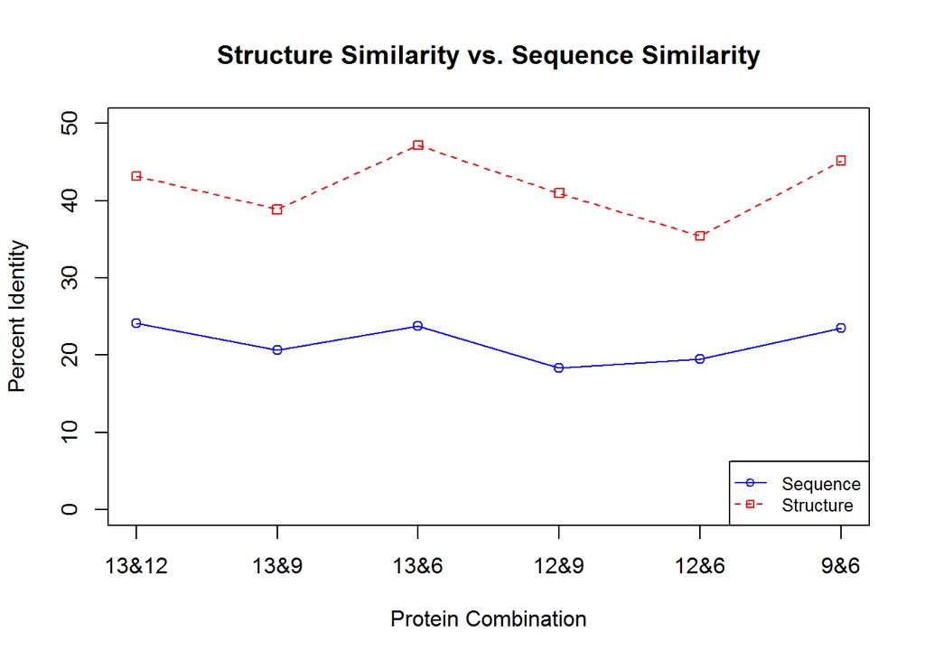

```r
#Plot Similarity
similar <- read.csv("C:/Users/hamrejr/Pictures/GMU/Vaisman/sim.csv", header=T)
x <- c(24.12,20.63,23.79,18.39,19.54,23.55)
y <- c( 43.19,38.89,47.18,41,35.43,45.17)
plot(x, col ="blue", type="o", ylim = c(0,50), ylab="Percent Identity", main="Structure Similarity vs. Sequence Similarity",xlab="Protein Combination",xaxt = "n")
axis(1, at=1:6, labels=similar$ï..ProteinComb)
lines(y, type="o", pch=22, lty=2, col="red")
legend( "bottomright",g_range[2], c("Sequence","Structure"), cex=0.8,
 col=c("blue","red"), pch=21:22, lty=1:2);
```

> Pearson correlation coefficient calculation

```r
cor(x, y, method=c("pearson"))
```

```
## [1] 0.7635051
```

> Scatter plot

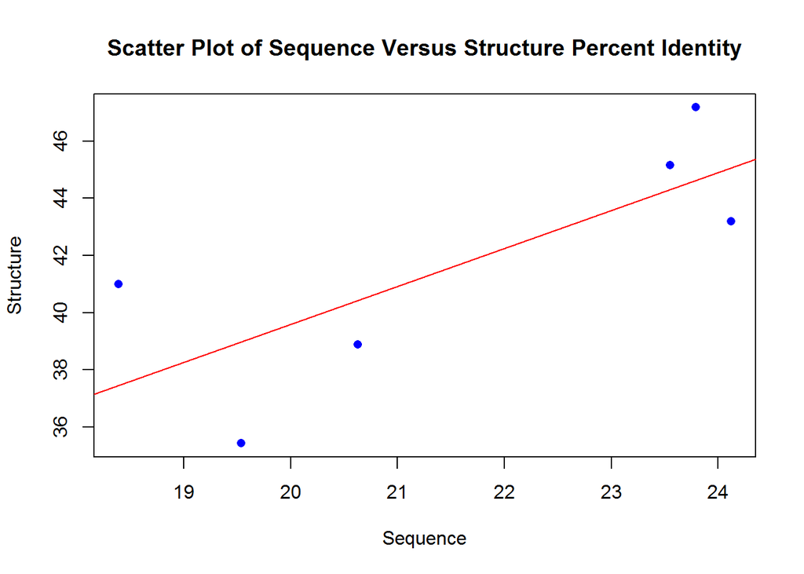

```r
plot(x,y, col="blue", pch=16, main="Scatter Plot of Sequence Versus Structure Percent Identity", xlab="Sequence", ylab="Structure")
abline(lm(y ~ x), col="red")
```

Visually, looking at both sequence and structure graphs, there appears to be a high degree of correlation between the two variables. When using the Pearson correlation function, a value of .764 was obtained, which also denotes a strong correlation. Further, a scatter plot showed that as sequence percent identity (X) increases the structure identity (Y) increased as well, which also indicates correlation.

Examination of the correlations between structure and sequence similarity for fragments of high and low sequence similarity, possible roles of the secondary structures within these associations, and the importance of structure conservation to functionally important sites

Clustal Omega color output was used for the initial inspection of multiple sequence alignments. This view allowed for visualizing similarities and dissimilarities of the sequences as well as an overall qualitative assessment of polar, hydrophobic, or reactive residues. [Interpro](https://www.ebi.ac.uk/interpro/) was then employed to locate domains and signature matches for each sequence and was able to find detailed relationships while also documenting the locations within the protein. For all 4 proteins, interpro located sequences that matched a P-loop containing nucleoside triphosphate hydrolase, an ABC transporter-like sequence, AAA+ ATPase domain, and an ABC transporter conserved site. [PROMALS](http://prodata.swmed.edu/promals/promals.php), a multiple structural alignment tool, was then used in conjunction with interpro to analyze secondary structure as it pertained to sequences and conserved domains. The default parameters were used and the fasta sequences were dropped in. [PROMALS output](http://prodata.swmed.edu/promals/getResult.php?name=QUERY_clGAvv) stays active for one month and displays red for alpha helices, blue for beta sheets, and a conservation index of each residue if it is calculated to be above 5. In many ways, the multiple secondary structure alignment of PROMALS was more informative than Clustal Omega multiple sequence alignments. PROMALS showed that the 4 protein sequences had almost identical numbers of beta sheets and alpha helixes between them, and that those secondary structures lined up very well for each protein.

In addition to the larger domains, signature motifs were also located with interpro and subsequently used for further analysis. For all 4 proteins, interpro located Walker A, Walker B, D-loop, H-loop, P-loop, and Q-loop motifs. These motifs were highly similar across all proteins used in the study and each motif relates to specific structure and functions that are used for ABC transportation. These motifs show a very strong correlation between sequence and structure. Most of these motifs have well documented sequences that do not change over time because of the essential protein functionality that would cease if any changes did in fact occur. For example, the WalkerA/P-loop contains the sequence G-XXXX-GK-[TS] and binds to the alpha and beta phosphates of di- and tri-nucleotides, ATP. The Q-loop, another motif necessary for protein functionality, contains an invariant glutamine (Q) and is thought to be the attacking nucleophile during ATP hydrolysis (5).

The Walker A/P-loop, followed by a 9-residue alpha helix, was also noted as one of the two regions found in this study with high sequence and structure similarity and high conservation indices. The other, the ABC transporter signature motif, also followed by an alpha helix (13-residues), was the second region noted for having high sequence identity. Both regions demonstrated 100 percent structure similarity between the proteins and contained an average of a 54% exact sequence match, well above the average match found for the entire length of the proteins, which was approximately 22% and can be observed in the plot above.

Several sequences of dissimilarity were located within the alignment also. The first observed location was directly after the glutamine in the Q-loop. Here, it was noted that there was an exact sequence identity average of only about 6%. Moreover, there were no secondary structures observed here. What this may suggest is that the structural diversity for atoms within the Q-loop are necessary for flexibility within that region, and recent supports this theory. A molecular dynamics simulation study found that the Q-loop undergoes conformational changes during the catalytic cycle and that Q-loop switching is coordinated with TMD and NBD conformational changes (6).

As established by the sequences found after the Q-loop, it is possible that regions where divergent sequences exist without secondary structure is where there may be a need for pliability. Other places a protein may need flexibility are turns between alpha helices or beta sheets. The PROMALS output showed that this was indeed the case in a few instances within these proteins.

In addition to divergent sequences with no structure, there were divergent sequences with conserved structure. One specific instance was found at approximate sequence locations of 170-190 for each protein, at the alpha helix directly following the H-loop. Here it was found that the average sequence identity of the first 10 residues in this specific helix was only 8%, less than half of the 22% average for the entire length of the proteins. This observation could indicate several things; The alpha helix found here, and similar structures conserved across proteins, are most likely structurally important but not functionally important. This is a bit of a misnomer because without this secondary structure the protein would not have the necessary structural integrity or shape that it needs, and therefore would not function. However, as far as how these sequence-divergent secondary structures relate to ATP-hydrolysis, or how they relate to any other specific ABC transport functionally important site, they may not play a role. Another possibility is that these structures are in the TMD domain. Here, they would mainly interact with the lipid bilayer, thus, if essential secondary structure is well-maintained it is of little importance which residue resides within the helix. Remaining a helix with the correct polarity is the only evolutionary requirement.

Lastly, where it was found that there are divergent sequences and divergent structures, the argument could be made that they are protein specific. For instance, in this set of 4 sequences, it was observed that protein number 6, the maltose transporter, was at least 54 residues longer than the other 3 proteins and that these residues contained several beta sheets. It is possible that these specific set of sequences and secondary structures are necessary for precise interactions involved with the transportation of the maltose molecules across the membrane.

## References

1. Verrier PJ, Bird D, Burla B. et al. (2008). Plant ABC proteins – A unified nomenclature and updated inventory. Trends Plant Sci. 13:151–159.
2. Dassa E, Bouige P. (2001). The ABC of ABCs: A phylogenetic and functional classification of ABC systems in living organisms. Res Microbiol., 152(3-4), 211–229.
3. Pathak, E., Atri, N., & Mishra, R. (2013). Role of highly central residues of P-loop and it’s flanking region in preserving the archetypal conformation of Walker A motif of diverse P-loop NTPases. Bioinformation, 9(1), 23–28.
4. Vasiliou, V., Vasiliou, K., & Nebert, D. W. (2009). Human ATP-binding cassette (ABC) transporter family. Human Genomics, 3(3), 281–290.
5. Gaudet, R., & Wiley, D. C. (2001). Structure of the ABC ATPase domain of human TAP1, the transporter associated with antigen processing. The EMBO Journal, 20(17), 4964–4972.
6. Jones, P. M., & George, A. M. (2002). Mechanism of ABC transporters: A molecular dynamics simulation of a well characterized nucleotide-binding subunit. Proceedings of the National Academy of Sciences of the United States of America, 99(20), 12639–12644.